# DATA 621 – Business Analytics and Data Mining

Homework 1

Ramnivas Singh

2022-03-06

# 1.0 Summary

In this homework assignment, you will explore, analyze and model a data set containing approximately 2200 records. Each record represents a professional baseball team from the years 1871 to 2006 inclusive. Each record has the performance of the team for the given year, with all of the statistics adjusted to match the performance of a 162 game season.

Your objective is to build a multiple linear regression model on the training data to predict the number of wins for the team. You can only use the variables given to you (or variables that you derive from the variables provided). Below is a short description of the variables of interest in the data set:

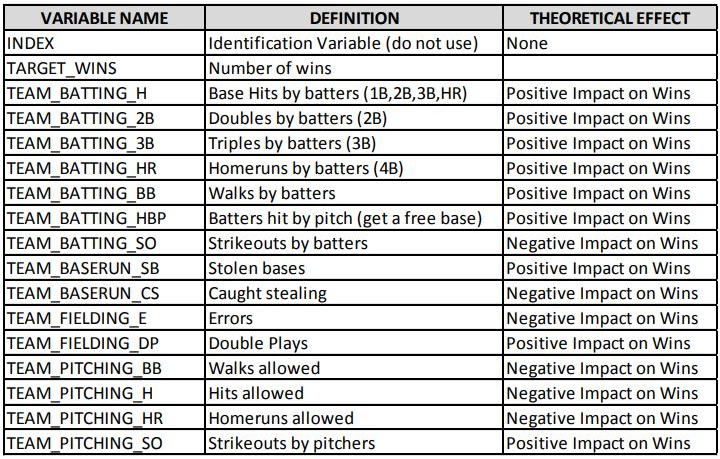

## Deliverables:

1. A write-up submitted in PDF format. Your write-up should have four sections. Each one is described below. You may assume you are addressing me as a fellow data scientist, so do not need to shy away from technical details.
2. Assigned predictions (the number of wins for the team) for the evaluation data set.
3. Include your R statistical programming code in an Appendix.

## Write-up sections :

1. Data Exploration
2. Data Preparation
3. Build Models
4. Select Models

# 2.0 Data Exploration

First of all, load the data and analyze to get some insights like summary, how the data got distributed and correlation between variables and understand the data by using stats, plots and summary. The objective of this is analysis is to develop a better understanding of the data to include its shape, central tendencies, completeness (missing data) and its correlation to our response variable Target_Wins.

```
##   TARGET_WINS     TEAM_BATTING_H TEAM_BATTING_2B TEAM_BATTING_3B
##  Min.   :  0.00   Min.   : 891   Min.   : 69.0   Min.   :  0.00
##  1st Qu.: 71.00   1st Qu.:1383   1st Qu.:208.0   1st Qu.: 34.00
##  Median : 82.00   Median :1454   Median :238.0   Median : 47.00
##  Mean   : 80.79   Mean   :1469   Mean   :241.2   Mean   : 55.25
##  3rd Qu.: 92.00   3rd Qu.:1537   3rd Qu.:273.0   3rd Qu.: 72.00
##  Max.   :146.00   Max.   :2554   Max.   :458.0   Max.   :223.00
##
##  TEAM_BATTING_HR  TEAM_BATTING_BB TEAM_BATTING_SO  TEAM_BASERUN_SB
##  Min.   :  0.00   Min.   :  0.0   Min.   :   0.0   Min.   :  0.0
##  1st Qu.: 42.00   1st Qu.:451.0   1st Qu.: 548.0   1st Qu.: 66.0
##  Median :102.00   Median :512.0   Median : 750.0   Median :101.0
##  Mean   : 99.61   Mean   :501.6   Mean   : 735.6   Mean   :124.8
##  3rd Qu.:147.00   3rd Qu.:580.0   3rd Qu.: 930.0   3rd Qu.:156.0
##  Max.   :264.00   Max.   :878.0   Max.   :1399.0   Max.   :697.0
##                                   NA's   :102      NA's   :131
##  TEAM_BASERUN_CS TEAM_BATTING_HBP TEAM_PITCHING_H TEAM_PITCHING_HR
##  Min.   :  0.0   Min.   :29.00    Min.   : 1137   Min.   :  0.0
##  1st Qu.: 38.0   1st Qu.:50.50    1st Qu.: 1419   1st Qu.: 50.0
##  Median : 49.0   Median :58.00    Median : 1518   Median :107.0
##  Mean   : 52.8   Mean   :59.36    Mean   : 1779   Mean   :105.7
##  3rd Qu.: 62.0   3rd Qu.:67.00    3rd Qu.: 1682   3rd Qu.:150.0
##  Max.   :201.0   Max.   :95.00    Max.   :30132   Max.   :343.0
##  NA's   :772     NA's   :2085
##  TEAM_PITCHING_BB TEAM_PITCHING_SO  TEAM_FIELDING_E  TEAM_FIELDING_DP
##  Min.   :   0.0   Min.   :    0.0   Min.   :  65.0   Min.   : 52.0
##  1st Qu.: 476.0   1st Qu.:  615.0   1st Qu.: 127.0   1st Qu.:131.0
##  Median : 536.5   Median :  813.5   Median : 159.0   Median :149.0
##  Mean   : 553.0   Mean   :  817.7   Mean   : 246.5   Mean   :146.4
##  3rd Qu.: 611.0   3rd Qu.:  968.0   3rd Qu.: 249.2   3rd Qu.:164.0
##  Max.   :3645.0   Max.   :19278.0   Max.   :1898.0   Max.   :228.0
##                   NA's   :102                        NA's   :286
```

```
##      n
## 1 2276
```

```
##  [1] "TARGET_WINS"      "TEAM_BATTING_H"   "TEAM_BATTING_2B"  "TEAM_BATTING_3B"
##  [5] "TEAM_BATTING_HR"  "TEAM_BATTING_BB"  "TEAM_BATTING_SO"  "TEAM_BASERUN_SB"
##  [9] "TEAM_BASERUN_CS"  "TEAM_BATTING_HBP" "TEAM_PITCHING_H"  "TEAM_PITCHING_HR"
## [13] "TEAM_PITCHING_BB" "TEAM_PITCHING_SO" "TEAM_FIELDING_E"  "TEAM_FIELDING_DP"
```

## View rows and columns, variable types

Glimpse of the data shows that all variables are numeric, no ctegorical variable is present here. We do lots of NA for few predcitors in the data set. In our further analysis we will try to identify :

- Structure of the each predictors
- How Many NA and Zero , is it significant to remove them or replace them with some predicted value.
- Statistical summary of the data

```
## Rows: 2,276
## Columns: 16
## $ TARGET_WINS      <int> 39, 70, 86, 70, 82, 75, 80, 85, 86, 76, 78, 68, 72, 7~
## $ TEAM_BATTING_H   <int> 1445, 1339, 1377, 1387, 1297, 1279, 1244, 1273, 1391,~
## $ TEAM_BATTING_2B  <int> 194, 219, 232, 209, 186, 200, 179, 171, 197, 213, 179~
## $ TEAM_BATTING_3B  <int> 39, 22, 35, 38, 27, 36, 54, 37, 40, 18, 27, 31, 41, 2~
## $ TEAM_BATTING_HR  <int> 13, 190, 137, 96, 102, 92, 122, 115, 114, 96, 82, 95,~
## $ TEAM_BATTING_BB  <int> 143, 685, 602, 451, 472, 443, 525, 456, 447, 441, 374~
## $ TEAM_BATTING_SO  <int> 842, 1075, 917, 922, 920, 973, 1062, 1027, 922, 827, ~
## $ TEAM_BASERUN_SB  <int> NA, 37, 46, 43, 49, 107, 80, 40, 69, 72, 60, 119, 221~
## $ TEAM_BASERUN_CS  <int> NA, 28, 27, 30, 39, 59, 54, 36, 27, 34, 39, 79, 109, ~
## $ TEAM_BATTING_HBP <int> NA, NA, NA, NA, NA, NA, NA, NA, NA, NA, NA, NA, NA, N~
## $ TEAM_PITCHING_H  <int> 9364, 1347, 1377, 1396, 1297, 1279, 1244, 1281, 1391,~
## $ TEAM_PITCHING_HR <int> 84, 191, 137, 97, 102, 92, 122, 116, 114, 96, 86, 95,~
## $ TEAM_PITCHING_BB <int> 927, 689, 602, 454, 472, 443, 525, 459, 447, 441, 391~
## $ TEAM_PITCHING_SO <int> 5456, 1082, 917, 928, 920, 973, 1062, 1033, 922, 827,~
## $ TEAM_FIELDING_E  <int> 1011, 193, 175, 164, 138, 123, 136, 112, 127, 131, 11~
## $ TEAM_FIELDING_DP <int> NA, 155, 153, 156, 168, 149, 186, 136, 169, 159, 141,~
```

```
##   TARGET_WINS TEAM_BATTING_H TEAM_BATTING_2B TEAM_BATTING_3B TEAM_BATTING_HR
## 1          39           1445             194              39              13
## 2          70           1339             219              22             190
## 3          86           1377             232              35             137
## 4          70           1387             209              38              96
## 5          82           1297             186              27             102
## 6          75           1279             200              36              92
##   TEAM_BATTING_BB TEAM_BATTING_SO TEAM_BASERUN_SB TEAM_BASERUN_CS
## 1             143             842              NA              NA
## 2             685            1075              37              28
## 3             602             917              46              27
## 4             451             922              43              30
## 5             472             920              49              39
## 6             443             973             107              59
##   TEAM_BATTING_HBP TEAM_PITCHING_H TEAM_PITCHING_HR TEAM_PITCHING_BB
## 1               NA            9364               84              927
## 2               NA            1347              191              689
## 3               NA            1377              137              602
## 4               NA            1396               97              454
## 5               NA            1297              102              472
## 6               NA            1279               92              443
##   TEAM_PITCHING_SO TEAM_FIELDING_E TEAM_FIELDING_DP
## 1             5456            1011               NA
## 2             1082             193              155
## 3              917             175              153
## 4              928             164              156
## 5              920             138              168
## 6              973             123              149
```

Show entire dataset of training data

[output not shown]

[output cut: 2266 more lines]

Here are some key points from data exploration:

- here are multiple variables with missing (NA) values and TEAM-BATTING_HBP has the highest NAs.
- The data is generally complete, however, six variables have missing data.
- The lowest complete rate is for the variable Hit By Pitch, with a rate of only 8%.
- The data set includes 2276 rows, 16 columns with all variables are numeric
- The response variable appears to be normally or near-normally distributed.

## Additional Data Exploration

### Skewness in the data :

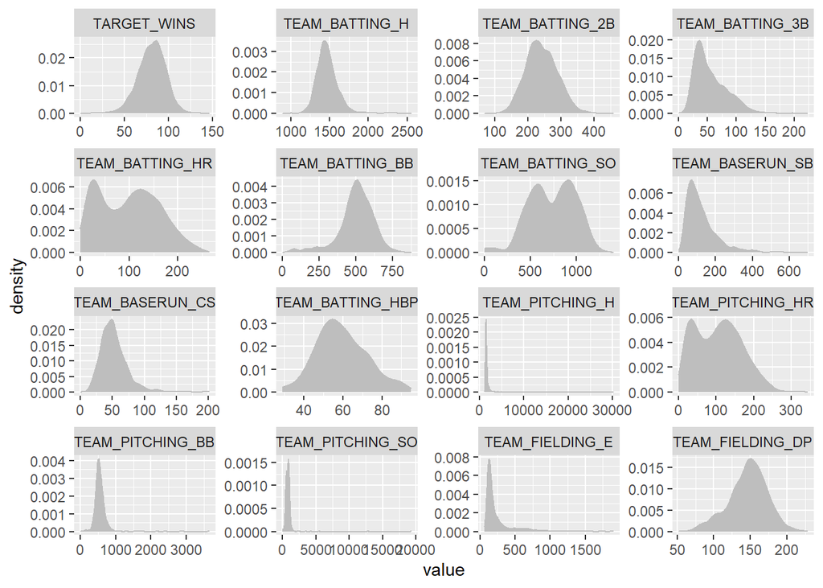

The majority of the explanatory variables appear to be normal or near-normal. There are however, several variable that have bi-modal distributions (Batting_HR, SO, Pitching_HR, Batting_SO) and others that are right-skewed (Fielding, Pitching_BB, Pitching_H)

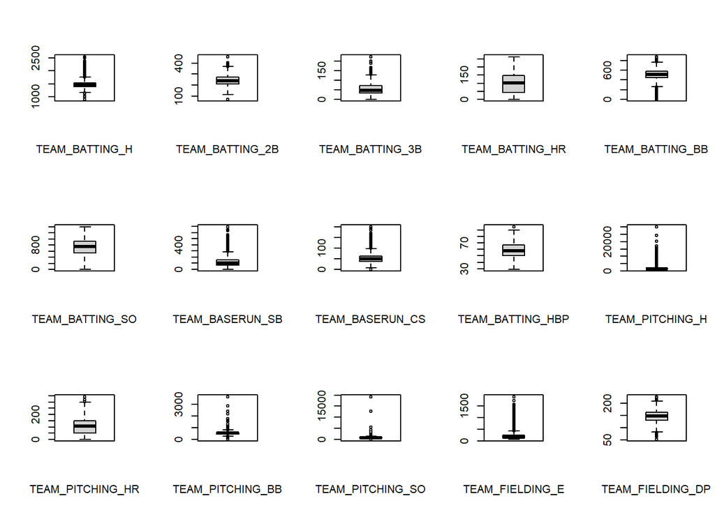

### Response Variable & Correlations

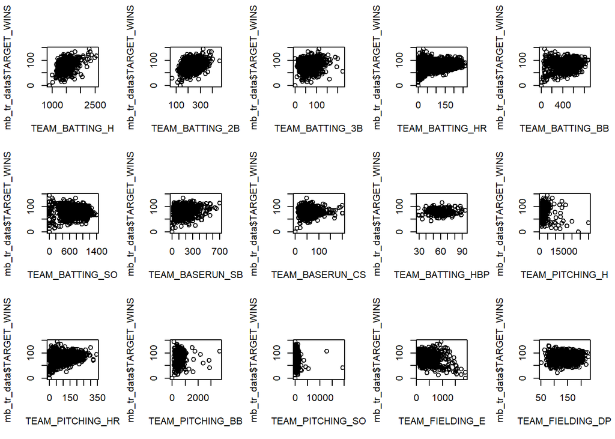

```
##  [1] "TEAM_BATTING_H"   "TEAM_BATTING_2B"  "TEAM_BATTING_3B"  "TEAM_BATTING_HR"
##  [5] "TEAM_BATTING_BB"  "TEAM_BATTING_SO"  "TEAM_BASERUN_SB"  "TEAM_BASERUN_CS"
##  [9] "TEAM_BATTING_HBP" "TEAM_PITCHING_H"  "TEAM_PITCHING_HR" "TEAM_PITCHING_BB"
## [13] "TEAM_PITCHING_SO" "TEAM_FIELDING_E"  "TEAM_FIELDING_DP"
```

```
##                  TEAM_BATTING_H TEAM_BATTING_2B TEAM_BATTING_3B TEAM_BATTING_HR
## TEAM_BATTING_H       1.00000000      0.56177286      0.21391883      0.39627593
## TEAM_BATTING_2B      0.56177286      1.00000000      0.04203441      0.25099045
## TEAM_BATTING_3B      0.21391883      0.04203441      1.00000000     -0.21879927
## TEAM_BATTING_HR      0.39627593      0.25099045     -0.21879927      1.00000000
## TEAM_BATTING_BB      0.19735234      0.19749256     -0.20584392      0.45638161
## TEAM_BATTING_SO     -0.34174328     -0.06415123     -0.19291841      0.21045444
## TEAM_BASERUN_SB      0.07167495     -0.18768279      0.16946086     -0.19021893
## TEAM_BASERUN_CS     -0.09377545     -0.20413884      0.23213978     -0.27579838
## TEAM_BATTING_HBP    -0.02911218      0.04608475     -0.17424715      0.10618116
## TEAM_PITCHING_H      0.99919269      0.56045355      0.21250322      0.39549390
## TEAM_PITCHING_HR     0.39495630      0.24999875     -0.21973263      0.99993259
## TEAM_PITCHING_BB     0.19529071      0.19592157     -0.20675383      0.45542468
## TEAM_PITCHING_SO    -0.34445001     -0.06616615     -0.19386654      0.20829574
## TEAM_FIELDING_E     -0.25381638     -0.19427027     -0.06513145      0.01567397
## TEAM_FIELDING_DP     0.01776946     -0.02488808      0.13314758     -0.06182222
##                  TEAM_BATTING_BB TEAM_BATTING_SO TEAM_BASERUN_SB
## TEAM_BATTING_H        0.19735234     -0.34174328      0.07167495
## TEAM_BATTING_2B       0.19749256     -0.06415123     -0.18768279
## TEAM_BATTING_3B      -0.20584392     -0.19291841      0.16946086
## TEAM_BATTING_HR       0.45638161      0.21045444     -0.19021893
## TEAM_BATTING_BB       1.00000000      0.21833871     -0.08806123
## TEAM_BATTING_SO       0.21833871      1.00000000     -0.07475974
## TEAM_BASERUN_SB      -0.08806123     -0.07475974      1.00000000
## TEAM_BASERUN_CS      -0.20878051     -0.05613035      0.62473781
## TEAM_BATTING_HBP      0.04746007      0.22094219     -0.06400498
## TEAM_PITCHING_H       0.19848687     -0.34145321      0.07395373
## TEAM_PITCHING_HR      0.45659283      0.21111617     -0.18948057
## TEAM_PITCHING_BB      0.99988140      0.21895783     -0.08741902
## TEAM_PITCHING_SO      0.21793253      0.99976835     -0.07351325
## TEAM_FIELDING_E      -0.07847126      0.30814540      0.04292341
## TEAM_FIELDING_DP     -0.07929078     -0.12319072     -0.13023054
##                  TEAM_BASERUN_CS TEAM_BATTING_HBP TEAM_PITCHING_H
## TEAM_BATTING_H      -0.093775445      -0.02911218      0.99919269
## TEAM_BATTING_2B     -0.204138837       0.04608475      0.56045355
## TEAM_BATTING_3B      0.232139777      -0.17424715      0.21250322
## TEAM_BATTING_HR     -0.275798375       0.10618116      0.39549390
## TEAM_BATTING_BB     -0.208780510       0.04746007      0.19848687
## TEAM_BATTING_SO     -0.056130355       0.22094219     -0.34145321
## TEAM_BASERUN_SB      0.624737808      -0.06400498      0.07395373
```

[output cut: 25 more lines]

```
## TEAM_BATTING_H       -0.25381638      0.017769456
## TEAM_BATTING_2B      -0.19427027     -0.024888081
## TEAM_BATTING_3B      -0.06513145      0.133147578
## TEAM_BATTING_HR       0.01567397     -0.061822219
## TEAM_BATTING_BB      -0.07847126     -0.079290775
## TEAM_BATTING_SO       0.30814540     -0.123190715
## TEAM_BASERUN_SB       0.04292341     -0.130230537
## TEAM_BASERUN_CS       0.20770119     -0.006764233
## TEAM_BATTING_HBP      0.04178971     -0.071208241
## TEAM_PITCHING_H      -0.25073028      0.014168073
## TEAM_PITCHING_HR      0.01689330     -0.062924751
## TEAM_PITCHING_BB     -0.07692315     -0.080406452
## TEAM_PITCHING_SO      0.31008407     -0.124923213
## TEAM_FIELDING_E       1.00000000      0.040205814
## TEAM_FIELDING_DP      0.04020581      1.000000000
```

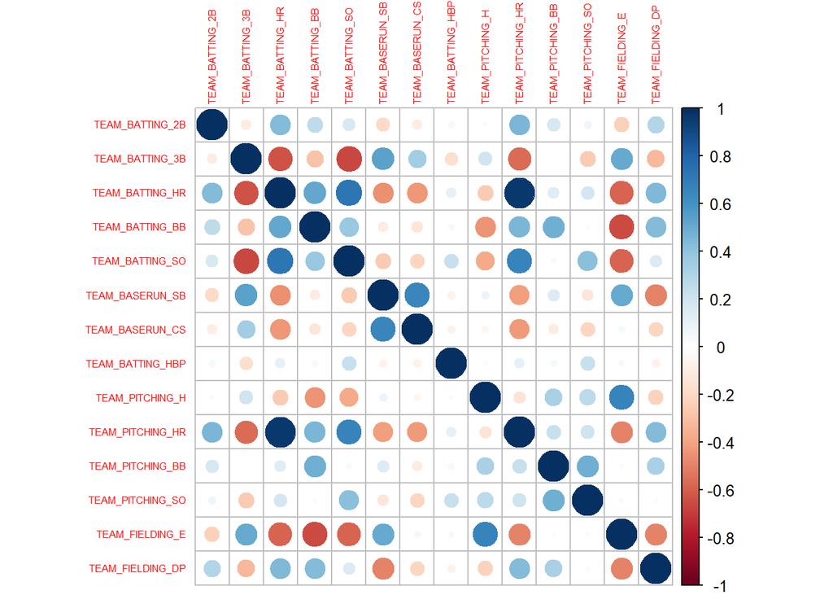

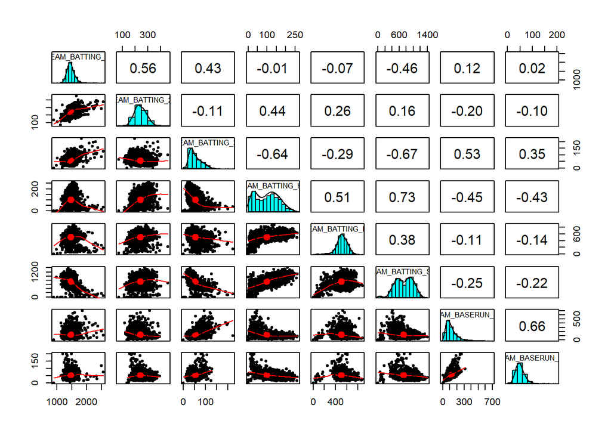

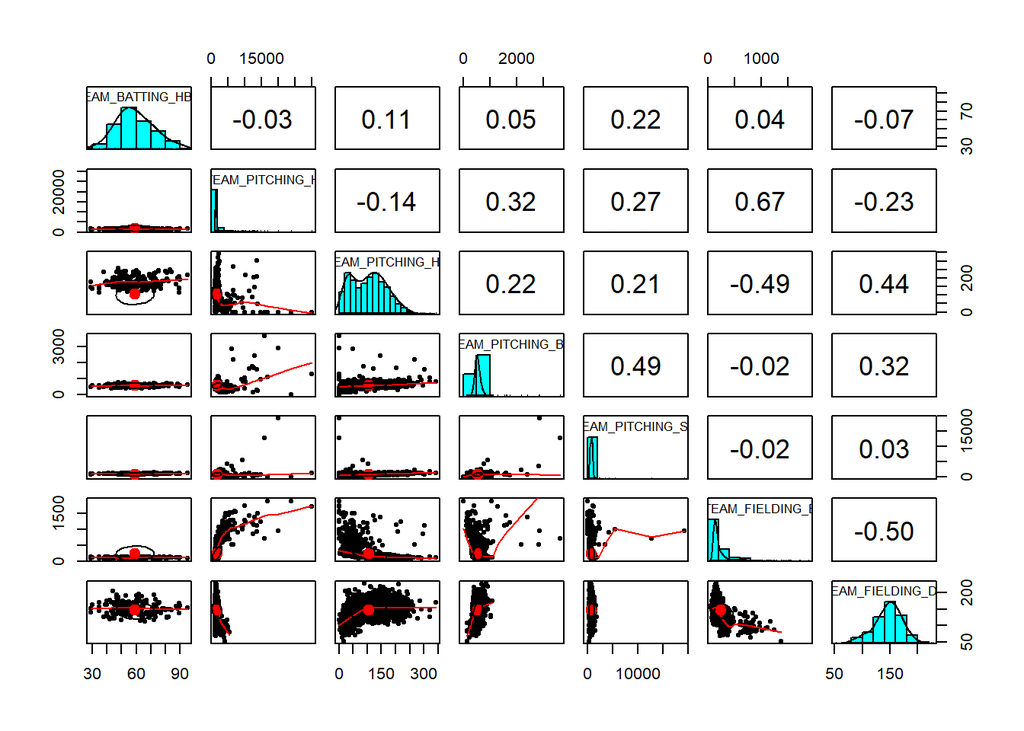

### Outliers

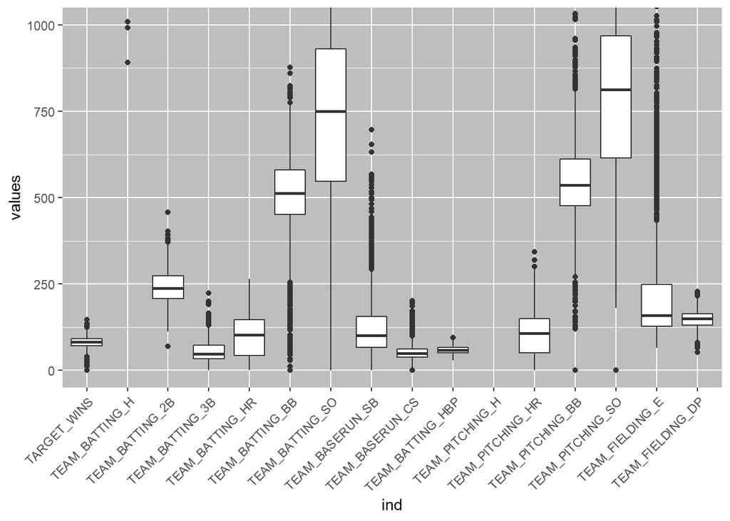

### Missing, NA and Zero

We are trying to see how many `NA` is present in the dataset.

| variable | n | percent |
| --- | --- | --- |
| TEAM_BATTING_HBP | 2085 | 92% |
| TEAM_BASERUN_CS | 772 | 34% |
| TEAM_FIELDING_DP | 286 | 13% |
| TEAM_BASERUN_SB | 131 | 5.8% |
| TEAM_BATTING_SO | 102 | 4.5% |
| TEAM_PITCHING_SO | 102 | 4.5% |

| variable | n | percent |
| --- | --- | --- |
| TEAM_BATTING_SO | 20 | 0.9% |
| TEAM_PITCHING_SO | 20 | 0.9% |
| TEAM_BATTING_HR | 15 | 0.7% |
| TEAM_PITCHING_HR | 15 | 0.7% |
| TEAM_BASERUN_SB | 2 | 0.1% |
| TEAM_BATTING_3B | 2 | 0.1% |
| TARGET_WINS | 1 | 0% |
| TEAM_BASERUN_CS | 1 | 0% |
| TEAM_BATTING_BB | 1 | 0% |
| TEAM_PITCHING_BB | 1 | 0% |

As can be inferred from above, there are very few zero values exists.

# 3.0 Data Preparation

Data preparation will include addressing missing data, outliers and feature engineering or creating new variables.

```
##  [1] "TEAM_BATTING_H"   "TEAM_BATTING_2B"  "TEAM_BATTING_3B"  "TEAM_BATTING_HR"
##  [5] "TEAM_BATTING_BB"  "TEAM_BATTING_SO"  "TEAM_BASERUN_SB"  "TEAM_BASERUN_CS"
##  [9] "TEAM_BATTING_HBP" "TEAM_PITCHING_H"  "TEAM_PITCHING_HR" "TEAM_PITCHING_BB"
## [13] "TEAM_PITCHING_SO" "TEAM_FIELDING_E"  "TEAM_FIELDING_DP"
```

```
##  [1] "TEAM_BATTING_H"   "TEAM_BATTING_2B"  "TEAM_BATTING_3B"  "TEAM_BATTING_HR"
##  [5] "TEAM_BATTING_BB"  "TEAM_BATTING_SO"  "TEAM_BASERUN_SB"  "TEAM_BASERUN_CS"
##  [9] "TEAM_BATTING_HBP" "TEAM_PITCHING_HR" "TEAM_PITCHING_BB" "TEAM_PITCHING_SO"
## [13] "TEAM_FIELDING_E"  "TEAM_FIELDING_DP"
```

```
##  [1] "TEAM_BATTING_H"   "TEAM_BATTING_2B"  "TEAM_BATTING_3B"  "TEAM_BATTING_HR"
##  [5] "TEAM_BATTING_BB"  "TEAM_BATTING_SO"  "TEAM_BASERUN_SB"  "TEAM_BASERUN_CS"
##  [9] "TEAM_BATTING_HBP" "TEAM_PITCHING_HR" "TEAM_PITCHING_SO" "TEAM_FIELDING_E"
## [13] "TEAM_FIELDING_DP"
```

Imputing the NAs using Mice(pmm - predictive mean matching)

```
##  TEAM_BATTING_H TEAM_BATTING_2B TEAM_BATTING_3B  TEAM_BATTING_HR
##  Min.   : 891   Min.   : 69.0   Min.   :  0.00   Min.   :  0.00
##  1st Qu.:1383   1st Qu.:208.0   1st Qu.: 34.00   1st Qu.: 42.00
##  Median :1454   Median :238.0   Median : 47.00   Median :102.00
##  Mean   :1469   Mean   :241.2   Mean   : 55.25   Mean   : 99.61
##  3rd Qu.:1537   3rd Qu.:273.0   3rd Qu.: 72.00   3rd Qu.:147.00
##  Max.   :2554   Max.   :458.0   Max.   :223.00   Max.   :264.00
##  TEAM_BATTING_BB TEAM_BATTING_SO  TEAM_BASERUN_SB TEAM_BASERUN_CS
##  Min.   :  0.0   Min.   :   0.0   Min.   :  0     Min.   :  0.00
##  1st Qu.:451.0   1st Qu.: 542.8   1st Qu.: 67     1st Qu.: 42.00
##  Median :512.0   Median : 735.0   Median :105     Median : 56.00
##  Mean   :501.6   Mean   : 728.0   Mean   :132     Mean   : 73.34
##  3rd Qu.:580.0   3rd Qu.: 925.0   3rd Qu.:166     3rd Qu.: 85.25
##  Max.   :878.0   Max.   :1399.0   Max.   :697     Max.   :201.00
##  TEAM_BATTING_HBP TEAM_PITCHING_HR TEAM_PITCHING_SO  TEAM_FIELDING_E
##  Min.   :29.00    Min.   :  0.0    Min.   :    0.0   Min.   :  65.0
##  1st Qu.:51.00    1st Qu.: 50.0    1st Qu.:  612.0   1st Qu.: 127.0
##  Median :51.00    Median :107.0    Median :  805.0   Median : 159.0
##  Mean   :52.44    Mean   :105.7    Mean   :  811.8   Mean   : 246.5
##  3rd Qu.:56.00    3rd Qu.:150.0    3rd Qu.:  961.0   3rd Qu.: 249.2
##  Max.   :95.00    Max.   :343.0    Max.   :19278.0   Max.   :1898.0
##  TEAM_FIELDING_DP
##  Min.   : 52.0
##  1st Qu.:124.0
##  Median :145.0
##  Mean   :141.3
##  3rd Qu.:162.0
##  Max.   :228.0
```

Centering and scaling was used to transform individual predictors in the dataset using the caret library.

```
##  t.TEAM_BATTING_H    t.TEAM_BATTING_2B  t.TEAM_BATTING_3B t.TEAM_BATTING_HR
##  Min.   :-7.537074   Min.   :-4.48108   Min.   :-1.9776   Min.   :-1.64521
##  1st Qu.:-0.573089   1st Qu.:-0.68949   1st Qu.:-0.7606   1st Qu.:-0.95153
##  Median :-0.003988   Median :-0.03019   Median :-0.2953   Median : 0.03944
##  Mean   : 0.000000   Mean   : 0.00000   Mean   : 0.0000   Mean   : 0.00000
##  3rd Qu.: 0.586908   3rd Qu.: 0.69827   3rd Qu.: 0.5995   3rd Qu.: 0.78267
##  Max.   : 4.390097   Max.   : 4.05391   Max.   : 6.0042   Max.   : 2.71505
##  t.TEAM_BATTING_BB  t.TEAM_BATTING_SO  t.TEAM_BASERUN_SB t.TEAM_BASERUN_CS
##  Min.   :-4.08866   Min.   :-2.95076   Min.   :-1.3897   Min.   :-1.5330
##  1st Qu.:-0.41215   1st Qu.:-0.75100   1st Qu.:-0.6841   1st Qu.:-0.6551
##  Median : 0.08511   Median : 0.02819   Median :-0.2838   Median :-0.3625
##  Mean   : 0.00000   Mean   : 0.00000   Mean   : 0.0000   Mean   : 0.0000
##  3rd Qu.: 0.63944   3rd Qu.: 0.79826   3rd Qu.: 0.3586   3rd Qu.: 0.2488
##  Max.   : 3.06871   Max.   : 2.71938   Max.   : 5.9511   Max.   : 2.6682
##  t.TEAM_BATTING_HBP t.TEAM_PITCHING_HR t.TEAM_PITCHING_SO t.TEAM_FIELDING_E
##  Min.   :-4.11371   Min.   :-1.72432   Min.   :-1.49540   Min.   :-3.3092
##  1st Qu.:-0.07987   1st Qu.:-0.90864   1st Qu.:-0.36802   1st Qu.:-0.7163
##  Median :-0.07987   Median : 0.02123   Median :-0.01249   Median :-0.1424
##  Mean   : 0.00000   Mean   : 0.00000   Mean   : 0.00000   Mean   : 0.0000
##  3rd Qu.: 0.52490   3rd Qu.: 0.72271   3rd Qu.: 0.27488   3rd Qu.: 0.7096
##  Max.   : 3.64121   Max.   : 3.87123   Max.   :34.01707   Max.   : 2.1432
##  t.TEAM_FIELDING_DP
##  Min.   :-2.53783
##  1st Qu.:-0.64889
##  Median : 0.06651
##  Mean   : 0.00000
##  3rd Qu.: 0.69350
##  Max.   : 3.50065
```

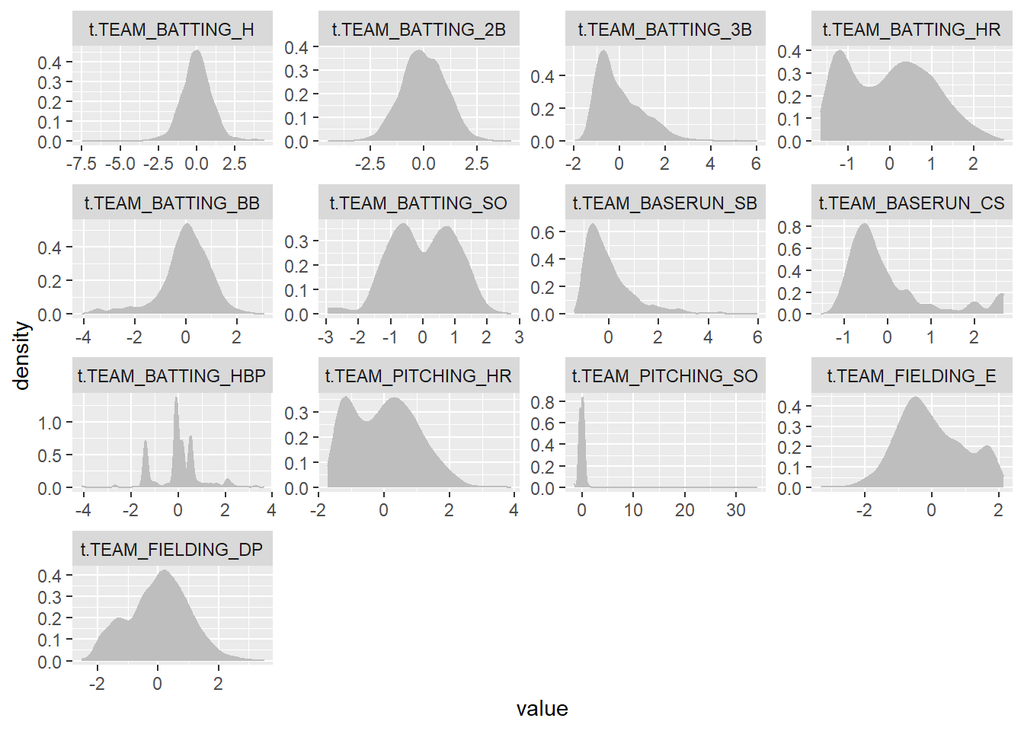

# 4.0 Build Models

Lets utilize the training data set to create the various models. Use selected variable to build several models to predict wins. The variables selected reflect my strategy of using variables that are related to runs scored and/or runs allowed. Next, in subsequent sections will select the best model and apply the test data set to that model.

```
## [1] "TEAM_BATTING_SO"  "TEAM_BASERUN_SB"  "TEAM_BASERUN_CS"  "TEAM_PITCHING_SO"
## [5] "TEAM_FIELDING_DP"
```

```
##   TARGET_WINS     TEAM_BATTING_BB TEAM_BATTING_SO  TEAM_BASERUN_SB
##  Min.   :  0.00   Min.   :  0.0   Min.   :   0.0   Min.   :  0.0
##  1st Qu.: 71.00   1st Qu.:451.0   1st Qu.: 556.8   1st Qu.: 67.0
##  Median : 82.00   Median :512.0   Median : 735.6   Median :106.0
##  Mean   : 80.79   Mean   :501.6   Mean   : 735.6   Mean   :124.8
##  3rd Qu.: 92.00   3rd Qu.:580.0   3rd Qu.: 925.0   3rd Qu.:151.0
##  Max.   :146.00   Max.   :878.0   Max.   :1399.0   Max.   :697.0
##  TEAM_BASERUN_CS  TEAM_PITCHING_H TEAM_PITCHING_HR TEAM_PITCHING_BB
##  Min.   :  0.00   Min.   : 1137   Min.   :  0.0    Min.   :   0.0
##  1st Qu.: 44.00   1st Qu.: 1419   1st Qu.: 50.0    1st Qu.: 476.0
##  Median : 52.80   Median : 1518   Median :107.0    Median : 536.5
##  Mean   : 52.80   Mean   : 1779   Mean   :105.7    Mean   : 553.0
##  3rd Qu.: 54.25   3rd Qu.: 1682   3rd Qu.:150.0    3rd Qu.: 611.0
##  Max.   :201.00   Max.   :30132   Max.   :343.0    Max.   :3645.0
##  TEAM_PITCHING_SO  TEAM_FIELDING_E  TEAM_FIELDING_DP TEAM_TOTAL_BASES
##  Min.   :    0.0   Min.   :  65.0   Min.   : 52.0    Min.   :1026
##  1st Qu.:  626.0   1st Qu.: 127.0   1st Qu.:134.0    1st Qu.:1947
##  Median :  817.7   Median : 159.0   Median :146.4    Median :2126
##  Mean   :  817.7   Mean   : 246.5   Mean   :146.4    Mean   :2120
##  3rd Qu.:  957.0   3rd Qu.: 249.2   3rd Qu.:161.2    3rd Qu.:2285
##  Max.   :19278.0   Max.   :1898.0   Max.   :228.0    Max.   :3290
```

```
##  TEAM_BATTING_BB  TEAM_BATTING_SO  TEAM_BASERUN_SB  TEAM_BASERUN_CS
##         5.480737         4.541755         1.785279         1.198380
##  TEAM_PITCHING_H TEAM_PITCHING_HR TEAM_PITCHING_BB TEAM_PITCHING_SO
##         3.362423         5.925567         4.922824         3.037166
##  TEAM_FIELDING_E TEAM_FIELDING_DP TEAM_TOTAL_BASES
##         4.120002         1.351790         2.865975
```

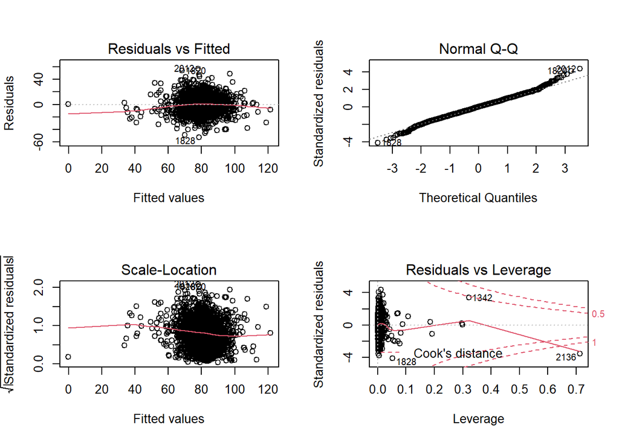

## Model 2 - Excludes variables based on possible Multicollinearity

```
##  TEAM_BATTING_BB  TEAM_BASERUN_SB  TEAM_BASERUN_CS TEAM_PITCHING_SO
##         2.166066         1.483321         1.143406         1.013311
##  TEAM_FIELDING_E TEAM_FIELDING_DP TEAM_TOTAL_BASES
##         2.221597         1.320254         1.214327
```

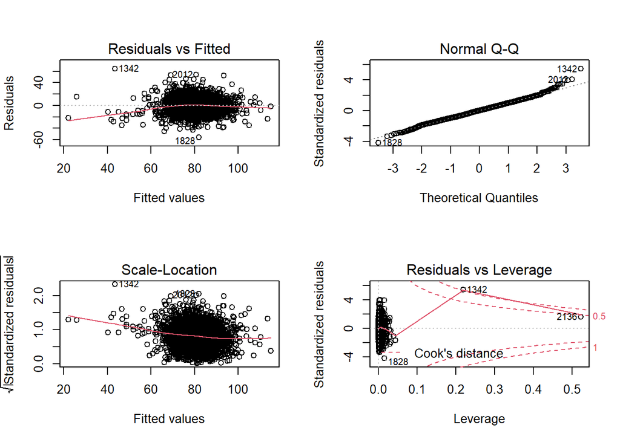

## Model 3 - Excludes variable based on insignificant P-value

```
##  TEAM_BATTING_BB  TEAM_BASERUN_SB TEAM_PITCHING_SO  TEAM_FIELDING_E
##         2.126959         1.357521         1.008308         2.154007
## TEAM_FIELDING_DP TEAM_TOTAL_BASES
##         1.320254         1.200559
```

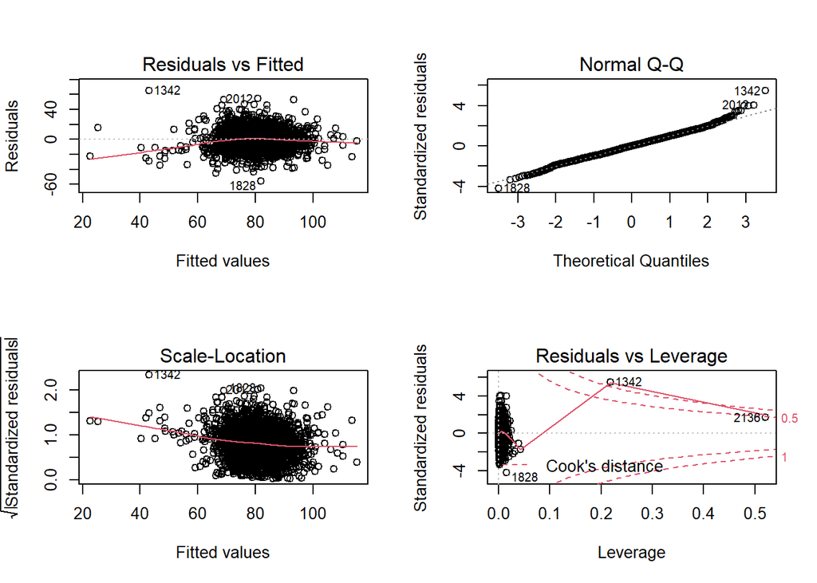

# 5.0 Select Models & Predictions

[output not shown]

[output not shown]

[output not shown]

## Predictions:

```
## [1] "TEAM_BATTING_SO"  "TEAM_BASERUN_SB"  "TEAM_BASERUN_CS"  "TEAM_PITCHING_SO"
## [5] "TEAM_FIELDING_DP"
```

```
##       fit              lwr              upr
##  Min.   : 30.63   Min.   : 2.583   Min.   : 58.67
##  1st Qu.: 75.68   1st Qu.:49.332   1st Qu.:102.02
##  Median : 81.31   Median :54.976   Median :107.65
##  Mean   : 80.46   Mean   :54.091   Mean   :106.82
##  3rd Qu.: 86.07   3rd Qu.:59.706   3rd Qu.:112.44
##  Max.   :106.95   Max.   :80.524   Max.   :133.37
```

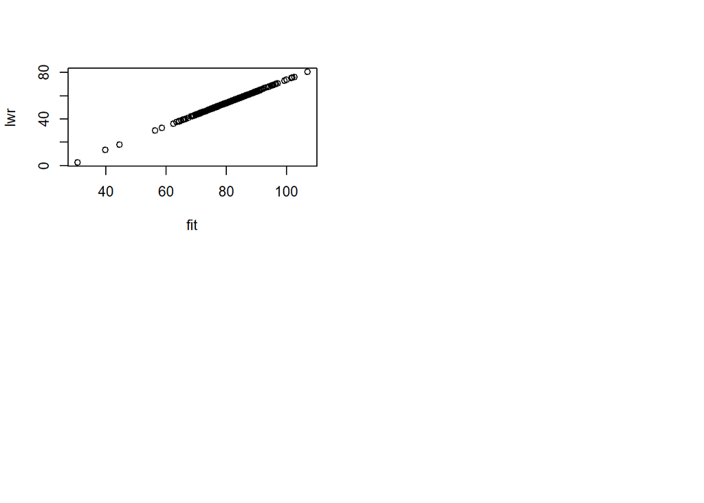

# 6.0 References

## Bibliography

Diez, D.M., Barr, C.D., & Cetinkaya-Rundel, M. (2015). OpenIntro Statistics, Third Edition. Open Source. Print

Faraway, J. J. (2015). Extending linear models with R, Second Edition. Boca Raton, FL: Chapman & Hall/CRC. Print

Fox, John (2016). Applied Regression Analysis and Generalized Linear Models, Third Edition. Los Angeles, CA: Sage. Print.

# 7.0 Resource Links

http://www.baseball-almanac.com/

http://tangotiger.net/wiki_archive/Base_Runs.html

https://www.kaggle.com/junkal/selecting-the-best-regression-model

https://www.listendata.com/2018/03/regression-analysis.html